## Data

The analysis involve five data sets involving international flights arriving to Chicago’s O’Hare airport from January 1, 2016 through June 30, 2020 with one separate file for each year.

Each data set is in five separate CSV files: `ORD-2016.csv`, `ORD-2017.csv`, `ORD-2018.csv`, `ORD-2019.csv`, and `ORD-2020.csv`.

> Read in the five data sets. Add columns for *year*, *month* (character valued, Jan-Dec), *day* (day of the month), and *wday* (day of the week, character valued, Sun - Sat). Reorder the variables so that these new variables all appear directly after date. Remove the terminal variable. Rename *all_total* to *passengers*, *all_flights* to *flights*, and *all_booths* to *booths*. Arrange the rows by date and hour.

```r
ord_2016 <- read_csv("data/ORD-2016.csv") %>%
  mutate(date = mdy(date))

ord_2017 <- read_csv("data/ORD-2017.csv") %>%
  mutate(date = mdy(date))

ord_2018 <- read_csv("data/ORD-2018.csv") %>%
  mutate(date = mdy(date))

ord_2019 <- read_csv("data/ORD-2019.csv") %>%
  mutate(date = ymd(date))

ord_2020 <- read_csv("data/ORD-2020.csv") %>%
  mutate(date = ymd(date))

data <- bind_rows(ord_2016, ord_2017,
                  ord_2018, ord_2019, ord_2020) %>%
  select(-terminal) %>%
  mutate(year = year(date)) %>%
  mutate(month = month(date, label = T)) %>%
  mutate(day = day(date)) %>%
  mutate(wday = wday(date, label = T)) %>%
  rename(passengers = all_total,
        flights = all_flights,
         booths = all_booths) %>%
  select(airport, date, year, month, day, wday, everything()) %>%
  arrange(date, hour)

rm(ord_2016)
rm(ord_2017)
rm(ord_2018)
rm(ord_2019)
rm(ord_2020)
```

## Analysis

> Check if there is any missing data Check if there are missing dates from January 1, 2016 through June 30, 2020

```r
missing_rows <- data %>%
  drop_na() %>%
  summarise(count = 29450 - n())

all_dates = tibble(
  date = seq(ymd("2016-01-01"), ymd("2020-06-30"), 1))

missing <- full_join(all_dates, select(data, date, flights)) %>%
  filter(is.na(flights)) %>%
  select(date)

rm(all_dates)
missing_rows
```

```
## # A tibble: 1 x 1
##   count
##   <dbl>
## 1     0
```

```r
missing
```

```
## # A tibble: 8 x 1
##   date
##   <date>
## 1 2016-03-07
## 2 2016-03-08
## 3 2016-03-09
## 4 2018-05-08
## 5 2019-10-28
## 6 2019-10-29
## 7 2019-10-30
## 8 2020-02-08
```

### Conclusions:

No rows contain missing data.

There are 8 dates missing, which are:

- 03/07/2016
- 03/08/2016
- 03/09/2016
- 05/08/2018
- 10/28/2019
- 10/29/2019
- 10/30/2019
- 02/08/2020

> Calculate the total numbers of flights and passengers in each month and year and store this information in a table. Summarize this table to find the total number of passengers and flights in each year from 2016 - 2019.

```r
total_year <- data %>%
  group_by(year, month) %>%
  summarise(total_flights = sum(flights),
            total_passengers = sum(passengers))

highest <- total_year %>%
  group_by(year) %>%
  summarise(flights = sum(total_flights),
            passengers = sum(total_passengers))

total_year
```

```
## # A tibble: 54 x 4
## # Groups:   year [5]
##     year month total_flights total_passengers
##    <dbl> <ord>         <dbl>            <dbl>
##  1  2016 Jan            2200           382618
##  2  2016 Feb            2008           297269
##  3  2016 Mar            2146           371282
##  4  2016 Apr            2211           397915
##  5  2016 May            2350           419454
##  6  2016 Jun            2394           471971
##  7  2016 Jul            2514           535122
##  8  2016 Aug            2396           509441
##  9  2016 Sep            2103           416257
## 10  2016 Oct            2033           387634
## # ... with 44 more rows
```

###Conclusions:

Year with highest total flights: 2018

Year with highest total passengers: 2019

> Display the total number of passengers by month and year with a bar chart where month is the primary variable on the x-axis and there is a separate bar (not stacked, and filled with a different color) for each year.

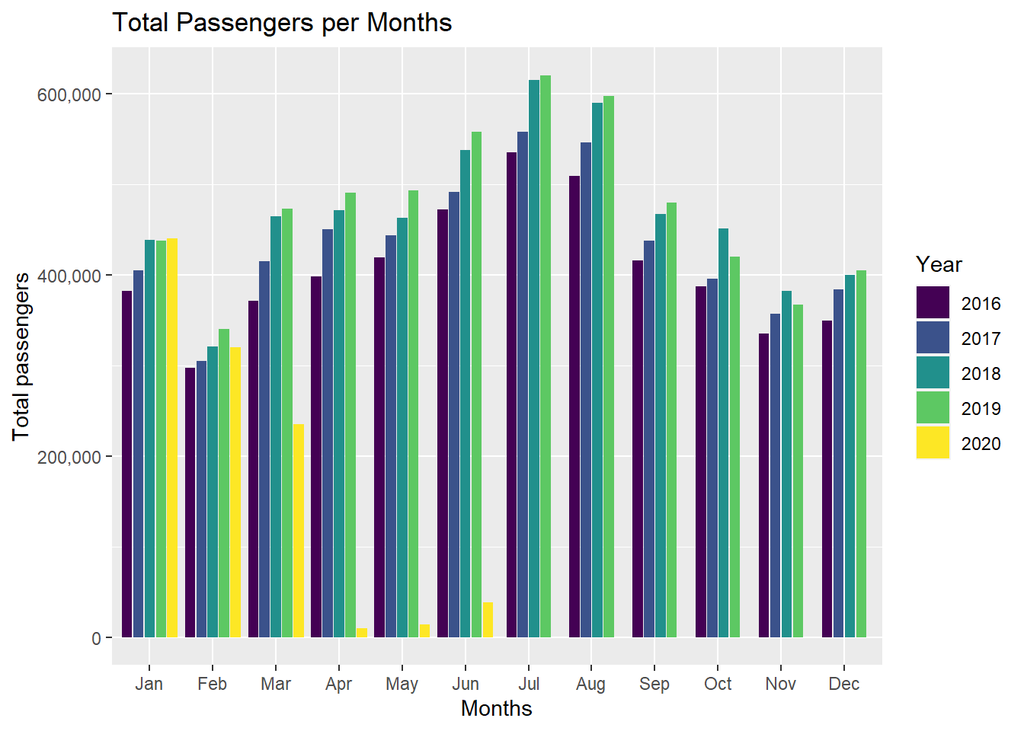

```r
ggplot(total_year) +
  geom_col(mapping = aes(x=month, y=total_passengers, fill=as.character(year)), position = position_dodge2(preserve = "single")) +
  scale_y_continuous(labels = scales::label_comma()) +
  scale_fill_discrete() +
  labs(fill = "Year") +
  xlab("Months") +
  ylab("Total passengers") +
  ggtitle("Total Passengers per Months")
```

### Conclusions:

> Add a `weekend` column to the combined data set which is TRUE for Saturdays and Sundays and FALSE for other days. Make a scatter plot with the average time for US passengers on the x-axis and the average time for non-US passengers on the y-axis. Use different colors for weekend and weekdays. Add straight regression lines to the plot, separately for weekends and weekdays Plot the data from different years in different facets.

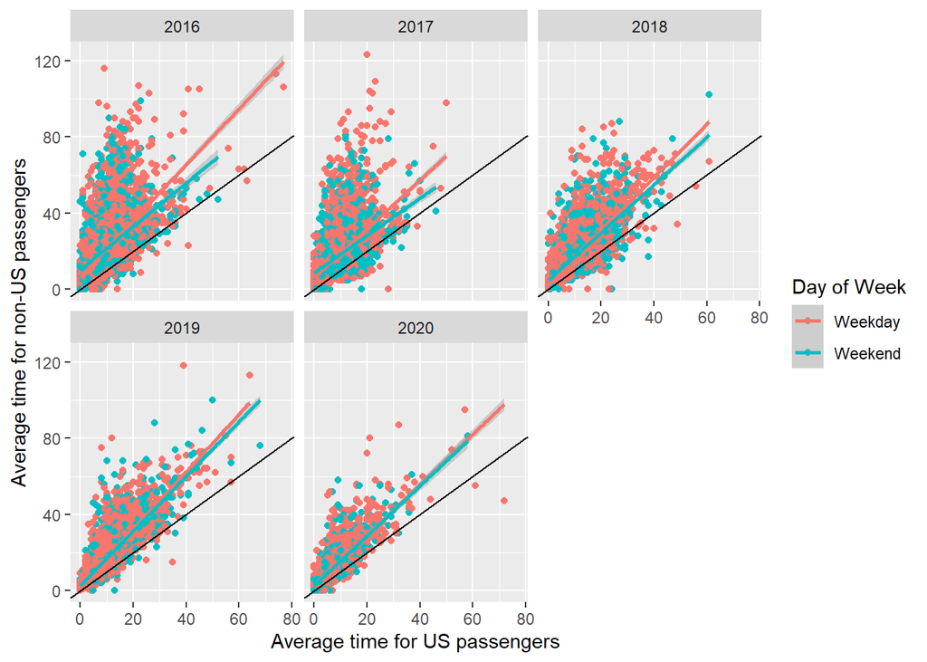

```r
data_weekend <- data %>%
  mutate(weekend = wday %in% c("Sat", "Sun"))

ggplot(data_weekend, aes(x=us_avg_wait, y = non_us_avg_wait, color = weekend)) +
  geom_point() +
  geom_abline(intercept = 0, slope = 1) +
  geom_smooth(method = "lm") +
  facet_wrap(~year) +
  scale_color_discrete(labels = c("Weekday", "Weekend"), name = "Day of Week") +
  xlab("Average time for US passengers") +
  ylab("Average time for non-US passengers")
```

### Conclusions:

The pattern is that the average wait time of non us and us flyers are positively correlated

> Calculate separately for each year, the fraction of cases (a case is a single hour on a single date) for which the average time to get through passport control is greater for non US passport holders than it is for passport holders. Comment on how these values relate to the graphs in the previous problem.

```r
q6 <- data %>%
  group_by(year) %>%
  summarise(sum = sum(us_avg_wait < non_us_avg_wait)/n())

q6
```

```
## # A tibble: 5 x 2
##    year   sum
##   <dbl> <dbl>
## 1  2016 0.914
## 2  2017 0.889
## 3  2018 0.919
## 4  2019 0.937
## 5  2020 0.875
```

### Conclusion:

Around 90% of the cases the non us flyers have to wait longer than the us flyers, which matches with the conclusions drawn from the graph above.

> Add a column named `booth_rate` to the data set which estimates the average number of passengers per booth per hour. For example, if 1000 passengers arrive between 05:00 and 06:00, the average wait time is 40 minutes, and there are 10 booths open, then an estimate of the total number of passengers per booth per hour could be computed like this: 1000/10 = 100 passengers per booth; (40 minutes per passenger * 1 hour per 60 minutes) = 2/3 hours per passenger; booth rate = 100 / (2/3) = (1000 * 60) / (10 * 40) = 150 passengers per booth per hour. This is an estimate because it assumes available booths change on the hour and it ignores how rates change when passenger wait durations stretch into the next time period. Add another column called `time_of_day` which takes the value “overnight” from 1am to 5am, “early morning” from 5am to 8am, “morning” from 8am to noon, “afternoon” from noon to 5pm, and “early evening” from 5pm to 8pm, and “late evening” from 8pm to 1am. Use `reorder()` to put the `time_of_day` variable in this order.

> Filter out cases where there are fewer than 200 total passengers, the average wait time is zero, or the booth rate is over 500. Make side_by_side boxplots of the booth rate versus the day of the week using different colors for each day of the week, different facets for each time of day, and fill color white if it is a weekday and gray if it is on the weekend.

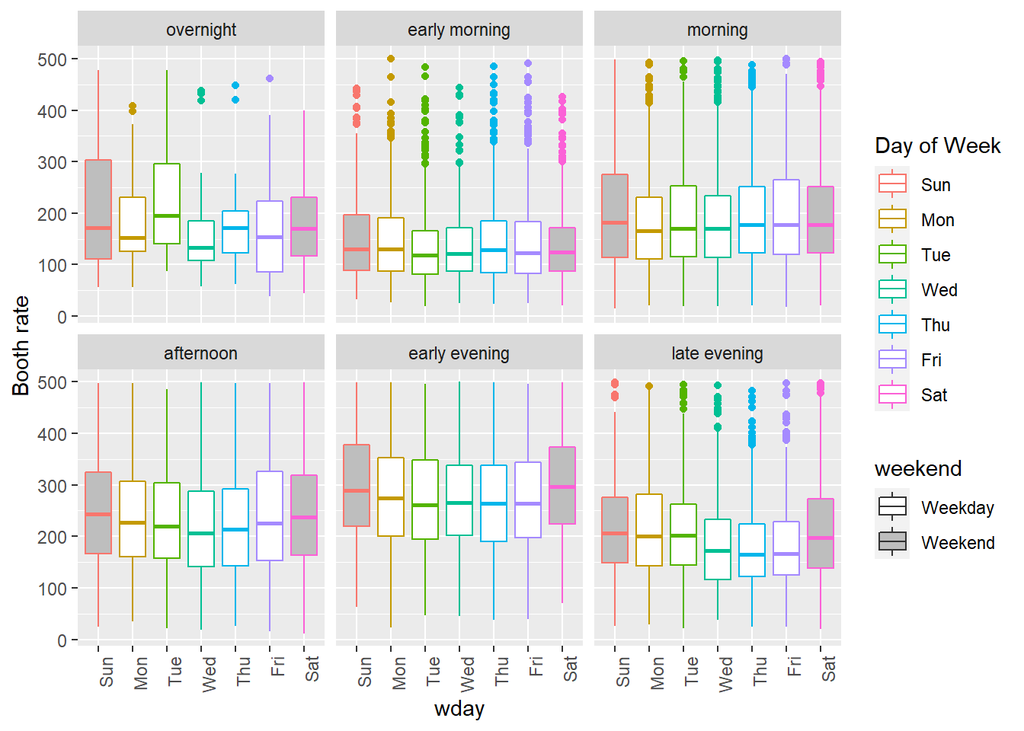

```r
q7 <- data_weekend %>%
  mutate(booth_rate = passengers/booths/all_avg_wait*60) %>%
  separate(hour, into = c("start", "end"), remove=F) %>%
  separate(start, into = c("start", "minute"), sep = 2) %>%
  mutate(start = as.numeric(start)) %>%
  select(-minute) %>%
  separate(end, into = c("end", "minute"), sep = 2) %>%
  select(-minute) %>%
  mutate(end = as.numeric(end)) %>%
  mutate(time_of_day = case_when(
    (start >= 1 & end <= 5 & end != 0) ~ "overnight",
    start >= 5 & end <=8 & end != 0 ~ "early morning",
    start >= 8 & end <= 12 & end != 0 ~ "morning",
    start >= 12 & end <= 17 & end != 0 ~ "afternoon",
    start >= 17 &end <= 20 & end != 0 ~ "early evening",
    TRUE ~ "late evening"
  )) %>%
  mutate(order = case_when(
    time_of_day == "overnight" ~ 1,
    time_of_day == "early morning" ~2,
    time_of_day == "morning" ~ 3,
    time_of_day == "afternoon" ~ 4,
    time_of_day == "early evening" ~ 5,
    time_of_day == "late evening" ~ 6,
  )) %>%
  mutate(time_of_day = reorder(time_of_day, order)) %>%
  filter(!(passengers < 200 | all_avg_wait == 0 | booth_rate > 500))

ggplot(q7) +
  geom_boxplot(mapping = aes(y = booth_rate, x = wday, color = wday, fill = weekend)) +
  scale_fill_manual(values=c("white", "gray"), labels = c("Weekday", "Weekend")) +
  facet_wrap(~time_of_day) +
  scale_color_discrete(name = "Day of Week") +
  ylab("Booth rate") +
  theme(axis.text.x = element_text(angle = 90, hjust=1))
```

### Conclusions:

- Early morning has the lowest booth rate
- Booth rates tend to be higher on the weekend during the afternoon and early evening, otherwise, the booth rates of weekend and weekdays are close to each other for the other time of the day
- This effect is quite small in comparison to the variation in the booth rate within a day of week and time of day